# Practice Machine Learning Project: fit band analysis

Francisco González Alonso

2016/09/11

# INTRODUCTION

Using devices such as Jawbone Up, Nike FuelBand, and Fitbit it is now possible to collect a large amount of data about personal activity relatively inexpensively. These type of devices are part of the quantified self movement - a group of enthusiasts who take measurements about themselves regularly to improve their health, to find patterns in their behavior, or because they are tech geeks. One thing that people regularly do is quantify how much of a particular activity they do, but they rarely quantify how well they do it.

In this project, our goal will be to use data from accelerometers on the belt, forearm, arm, and dumbell of 6 participants. They were asked to perform barbell lifts correctly and incorrectly in 5 different ways. More information is available from the website here: http://groupware.les.inf.puc-rio.br/har (see the section on the Weight Lifting Exercise Dataset).

## Data Summary:

The training data for this project are available here:

https://d396qusza40orc.cloudfront.net/predmachlearn/pml-training.csv

The test data are available here:

https://d396qusza40orc.cloudfront.net/predmachlearn/pml-testing.csv

## Target

The goal of my project is to predict the manner in which they did the exercise. This is the “classe” variable in the training set. You may use any of the other variables to predict with.

You should create a report describing how you built your model, how you used cross validation, what you think the expected out of sample error is, and why you made the choices you did. You will also use your prediction model to predict 20 different test cases.

# PRELIMINARY ANALYSIS:

## Loading Library :

To do the study I will use the libraries: CARET and RANDOM FOREST.

```r
library(randomForest);
library(caret);
```

## loading Data:

I download the files and load them in different data frames.

```r
urlTraining <- "https://d396qusza40orc.cloudfront.net/predmachlearn/pml-training.csv";
urlTesting  <- "https://d396qusza40orc.cloudfront.net/predmachlearn/pml-testing.csv";
fileTraining <- "training.csv"
fileTesting  <- "testing.csv"

download.file(urlTraining, fileTraining);
download.file(urlTesting, fileTesting);
df.training <- read.csv(fileTraining, na.strings = c("NA", ""));
df.validation <- read.csv(fileTesting, na.strings = c("NA", ""));
```

## Data’s Overview:

My first step is compare the dimensions of both data sets:

```r
dim (df.training);
```

```
## [1] 19622   160
```

```r
##str(df.training);
dim(df.validation);
```

```
## [1]  20 160
```

```r
##str(df.validation);
```

They are similar in the number of columns, and the next step is verifying the name and class of the columns:

```r
compColNames<-names(df.training)==names(df.validation);
compColNames;
```

```
##   [1]  TRUE  TRUE  TRUE  TRUE  TRUE  TRUE  TRUE  TRUE  TRUE  TRUE  TRUE
##  [12]  TRUE  TRUE  TRUE  TRUE  TRUE  TRUE  TRUE  TRUE  TRUE  TRUE  TRUE
##  [23]  TRUE  TRUE  TRUE  TRUE  TRUE  TRUE  TRUE  TRUE  TRUE  TRUE  TRUE
##  [34]  TRUE  TRUE  TRUE  TRUE  TRUE  TRUE  TRUE  TRUE  TRUE  TRUE  TRUE
##  [45]  TRUE  TRUE  TRUE  TRUE  TRUE  TRUE  TRUE  TRUE  TRUE  TRUE  TRUE
##  [56]  TRUE  TRUE  TRUE  TRUE  TRUE  TRUE  TRUE  TRUE  TRUE  TRUE  TRUE
##  [67]  TRUE  TRUE  TRUE  TRUE  TRUE  TRUE  TRUE  TRUE  TRUE  TRUE  TRUE
##  [78]  TRUE  TRUE  TRUE  TRUE  TRUE  TRUE  TRUE  TRUE  TRUE  TRUE  TRUE
##  [89]  TRUE  TRUE  TRUE  TRUE  TRUE  TRUE  TRUE  TRUE  TRUE  TRUE  TRUE
## [100]  TRUE  TRUE  TRUE  TRUE  TRUE  TRUE  TRUE  TRUE  TRUE  TRUE  TRUE
## [111]  TRUE  TRUE  TRUE  TRUE  TRUE  TRUE  TRUE  TRUE  TRUE  TRUE  TRUE
## [122]  TRUE  TRUE  TRUE  TRUE  TRUE  TRUE  TRUE  TRUE  TRUE  TRUE  TRUE
## [133]  TRUE  TRUE  TRUE  TRUE  TRUE  TRUE  TRUE  TRUE  TRUE  TRUE  TRUE
## [144]  TRUE  TRUE  TRUE  TRUE  TRUE  TRUE  TRUE  TRUE  TRUE  TRUE  TRUE
## [155]  TRUE  TRUE  TRUE  TRUE  TRUE FALSE
```

```r
compColClass<-sapply(df.training, class)==sapply(df.validation, class);
compColClass;
```

```
##                        X                user_name     raw_timestamp_part_1
##                     TRUE                     TRUE                     TRUE
##     raw_timestamp_part_2           cvtd_timestamp               new_window
##                     TRUE                     TRUE                     TRUE
##               num_window                roll_belt               pitch_belt
##                     TRUE                     TRUE                     TRUE
##                 yaw_belt         total_accel_belt       kurtosis_roll_belt
##                     TRUE                     TRUE                    FALSE
##      kurtosis_picth_belt        kurtosis_yaw_belt       skewness_roll_belt
##                    FALSE                    FALSE                    FALSE
##     skewness_roll_belt.1        skewness_yaw_belt            max_roll_belt
##                    FALSE                    FALSE                    FALSE
##           max_picth_belt             max_yaw_belt            min_roll_belt
##                    FALSE                    FALSE                    FALSE
##           min_pitch_belt             min_yaw_belt      amplitude_roll_belt
##                    FALSE                    FALSE                    FALSE
##     amplitude_pitch_belt       amplitude_yaw_belt     var_total_accel_belt
##                    FALSE                    FALSE                    FALSE
##            avg_roll_belt         stddev_roll_belt            var_roll_belt
##                    FALSE                    FALSE                    FALSE
##           avg_pitch_belt        stddev_pitch_belt           var_pitch_belt
##                    FALSE                    FALSE                    FALSE
##             avg_yaw_belt          stddev_yaw_belt             var_yaw_belt
##                    FALSE                    FALSE                    FALSE
##             gyros_belt_x             gyros_belt_y             gyros_belt_z
##                     TRUE                     TRUE                     TRUE
##             accel_belt_x             accel_belt_y             accel_belt_z
##                     TRUE                     TRUE                     TRUE
##            magnet_belt_x            magnet_belt_y            magnet_belt_z
##                     TRUE                     TRUE                     TRUE
##                 roll_arm                pitch_arm                  yaw_arm
##                     TRUE                     TRUE                     TRUE
##          total_accel_arm            var_accel_arm             avg_roll_arm
##                     TRUE                    FALSE                    FALSE
##          stddev_roll_arm             var_roll_arm            avg_pitch_arm
##                    FALSE                    FALSE                    FALSE
##         stddev_pitch_arm            var_pitch_arm              avg_yaw_arm
##                    FALSE                    FALSE                    FALSE
##           stddev_yaw_arm              var_yaw_arm              gyros_arm_x
##                    FALSE                    FALSE                     TRUE
```

[output cut: 53 more lines]

```
##                    FALSE                     TRUE                    FALSE
##         avg_roll_forearm      stddev_roll_forearm         var_roll_forearm
##                    FALSE                    FALSE                    FALSE
##        avg_pitch_forearm     stddev_pitch_forearm        var_pitch_forearm
##                    FALSE                    FALSE                    FALSE
##          avg_yaw_forearm       stddev_yaw_forearm          var_yaw_forearm
##                    FALSE                    FALSE                    FALSE
##          gyros_forearm_x          gyros_forearm_y          gyros_forearm_z
##                     TRUE                     TRUE                     TRUE
##          accel_forearm_x          accel_forearm_y          accel_forearm_z
##                     TRUE                     TRUE                     TRUE
##         magnet_forearm_x         magnet_forearm_y         magnet_forearm_z
##                     TRUE                    FALSE                    FALSE
##                   classe
##                    FALSE
```

And I found differences in the last column of data sets::

```r
names(df.training)[!compColNames];
```

```
## [1] "classe"
```

```r
class(df.training[,!compColNames]);
```

```
## [1] "factor"
```

```r
names(df.validation)[!compColNames];
```

```
## [1] "problem_id"
```

```r
class(df.validation[,!compColNames]);
```

```
## [1] "integer"
```

Both in the name and class type.

And exists differences with the class type of variables, with the same name:

```r
sapply(df.training[,compColClass], class);
```

```
##                    X            user_name raw_timestamp_part_1
##            "integer"             "factor"            "integer"
## raw_timestamp_part_2       cvtd_timestamp           new_window
##            "integer"             "factor"             "factor"
##           num_window            roll_belt           pitch_belt
##            "integer"            "numeric"            "numeric"
##             yaw_belt     total_accel_belt         gyros_belt_x
##            "numeric"            "integer"            "numeric"
##         gyros_belt_y         gyros_belt_z         accel_belt_x
##            "numeric"            "numeric"            "integer"
##         accel_belt_y         accel_belt_z        magnet_belt_x
##            "integer"            "integer"            "integer"
##        magnet_belt_y        magnet_belt_z             roll_arm
##            "integer"            "integer"            "numeric"
##            pitch_arm              yaw_arm      total_accel_arm
##            "numeric"            "numeric"            "integer"
##          gyros_arm_x          gyros_arm_y          gyros_arm_z
##            "numeric"            "numeric"            "numeric"
##          accel_arm_x          accel_arm_y          accel_arm_z
##            "integer"            "integer"            "integer"
##         magnet_arm_x         magnet_arm_y         magnet_arm_z
##            "integer"            "integer"            "integer"
##        roll_dumbbell       pitch_dumbbell         yaw_dumbbell
##            "numeric"            "numeric"            "numeric"
## total_accel_dumbbell     gyros_dumbbell_x     gyros_dumbbell_y
##            "integer"            "numeric"            "numeric"
##     gyros_dumbbell_z     accel_dumbbell_x     accel_dumbbell_y
##            "numeric"            "integer"            "integer"
##     accel_dumbbell_z    magnet_dumbbell_x    magnet_dumbbell_y
##            "integer"            "integer"            "integer"
##         roll_forearm        pitch_forearm          yaw_forearm
##            "numeric"            "numeric"            "numeric"
##  total_accel_forearm      gyros_forearm_x      gyros_forearm_y
##            "integer"            "numeric"            "numeric"
##      gyros_forearm_z      accel_forearm_x      accel_forearm_y
##            "numeric"            "integer"            "integer"
##      accel_forearm_z     magnet_forearm_x
##            "integer"            "integer"
```

```r
sapply(df.validation[,compColClass], class);
```

```
##                    X            user_name raw_timestamp_part_1
##            "integer"             "factor"            "integer"
## raw_timestamp_part_2       cvtd_timestamp           new_window
##            "integer"             "factor"             "factor"
##           num_window            roll_belt           pitch_belt
##            "integer"            "numeric"            "numeric"
##             yaw_belt     total_accel_belt         gyros_belt_x
##            "numeric"            "integer"            "numeric"
##         gyros_belt_y         gyros_belt_z         accel_belt_x
##            "numeric"            "numeric"            "integer"
##         accel_belt_y         accel_belt_z        magnet_belt_x
##            "integer"            "integer"            "integer"
##        magnet_belt_y        magnet_belt_z             roll_arm
##            "integer"            "integer"            "numeric"
##            pitch_arm              yaw_arm      total_accel_arm
##            "numeric"            "numeric"            "integer"
##          gyros_arm_x          gyros_arm_y          gyros_arm_z
##            "numeric"            "numeric"            "numeric"
##          accel_arm_x          accel_arm_y          accel_arm_z
##            "integer"            "integer"            "integer"
##         magnet_arm_x         magnet_arm_y         magnet_arm_z
##            "integer"            "integer"            "integer"
##        roll_dumbbell       pitch_dumbbell         yaw_dumbbell
##            "numeric"            "numeric"            "numeric"
## total_accel_dumbbell     gyros_dumbbell_x     gyros_dumbbell_y
##            "integer"            "numeric"            "numeric"
##     gyros_dumbbell_z     accel_dumbbell_x     accel_dumbbell_y
##            "numeric"            "integer"            "integer"
##     accel_dumbbell_z    magnet_dumbbell_x    magnet_dumbbell_y
##            "integer"            "integer"            "integer"
##         roll_forearm        pitch_forearm          yaw_forearm
##            "numeric"            "numeric"            "numeric"
##  total_accel_forearm      gyros_forearm_x      gyros_forearm_y
##            "integer"            "numeric"            "numeric"
##      gyros_forearm_z      accel_forearm_x      accel_forearm_y
##            "numeric"            "integer"            "integer"
##      accel_forearm_z     magnet_forearm_x
##            "integer"            "integer"
```

And thus i only will use to do my model the variables with the same name and class, except the seven first, because they are irrelevant:

```r
## Adding the last column "clasee" to training dataset:
compColClass[length(compColClass)] <-TRUE;

## Delete the seven first columns because are irrelevants
compColClass[1:7] <-FALSE;

## Select only the columns relevants
df.training<-df.training[,compColClass];
df.validation<-df.validation[,compColClass];

## Rename the problem_id to convert to classe column.
df.validation$problem_id<-""
colnames(df.validation)[ colnames(df.validation) == "problem_id" ] <- "classe"
df.validation$classe<-factor(df.validation$classe);
levels(df.validation$classe) <- levels(df.training$classe);
```

In the validation dataset the do not exist the “class” column and therefore it has not utility to test my future model, thus I need a split the training set to a new training and testing dataset .

However, i will use the validation set to will predict 20 different test cases.

## Creation of Testing Dataset :

For test my future model I will need do training the model with a set of data (training data set - 75%) and testing it with another set of data (testing data set -25% ).

I can create a new data sets, using the [createDataPartition function](http://topepo.github.io/caret/splitting.html) of caret package, using my original df.training dataset.

```r
set.seed(000000);
df.aux<-df.training;
trainIndex <- createDataPartition(df.aux$classe, p = .75, list = FALSE);
df.training <- df.aux[ trainIndex,];
df.testing  <- df.aux[-trainIndex,];
```

# PREPROCESSING DATA:

## NZV Analisys: detecting variables without variance.

I try to detect regressor variables without variance, for this I use the [nearZeroVar function](http://topepo.github.io/caret/preprocess.html#nzv) of caret package:

```r
nzv<- nearZeroVar(df.training, saveMetrics= TRUE);
nzv;
```

```
##                      freqRatio percentUnique zeroVar   nzv
## roll_belt             1.058224    7.94265525   FALSE FALSE
## pitch_belt            1.006849   11.63880962   FALSE FALSE
## yaw_belt              1.082051   12.43375459   FALSE FALSE
## total_accel_belt      1.072739    0.19703764   FALSE FALSE
## gyros_belt_x          1.100705    0.89686099   FALSE FALSE
## gyros_belt_y          1.167807    0.45522489   FALSE FALSE
## gyros_belt_z          1.045727    1.13466504   FALSE FALSE
## accel_belt_x          1.108014    1.09389863   FALSE FALSE
## accel_belt_y          1.142355    0.94442180   FALSE FALSE
## accel_belt_z          1.076805    1.97037641   FALSE FALSE
## magnet_belt_x         1.075540    2.05870363   FALSE FALSE
## magnet_belt_y         1.110187    1.97037641   FALSE FALSE
## magnet_belt_z         1.040462    2.97594782   FALSE FALSE
## roll_arm             52.632653   16.58513385   FALSE FALSE
## pitch_arm            86.000000   19.27571681   FALSE FALSE
## yaw_arm              33.934211   18.26335100   FALSE FALSE
## total_accel_arm       1.042879    0.44163609   FALSE FALSE
## gyros_arm_x           1.035714    4.32123930   FALSE FALSE
## gyros_arm_y           1.446701    2.48675092   FALSE FALSE
## gyros_arm_z           1.110276    1.59668433   FALSE FALSE
## accel_arm_x           1.048780    5.22489469   FALSE FALSE
## accel_arm_y           1.116279    3.59423835   FALSE FALSE
## accel_arm_z           1.009804    5.18412828   FALSE FALSE
## magnet_arm_x          1.000000    8.96860987   FALSE FALSE
## magnet_arm_y          1.031250    5.81600761   FALSE FALSE
## magnet_arm_z          1.095238    8.54735698   FALSE FALSE
## roll_dumbbell         1.029126   86.03071069   FALSE FALSE
## pitch_dumbbell        2.141509   83.93803506   FALSE FALSE
## yaw_dumbbell          1.152174   85.46677538   FALSE FALSE
## total_accel_dumbbell  1.046198    0.29215926   FALSE FALSE
## gyros_dumbbell_x      1.017699    1.58988993   FALSE FALSE
## gyros_dumbbell_y      1.256757    1.83448838   FALSE FALSE
## gyros_dumbbell_z      1.073227    1.34529148   FALSE FALSE
## accel_dumbbell_x      1.068826    2.81288219   FALSE FALSE
## accel_dumbbell_y      1.112903    3.09145264   FALSE FALSE
## accel_dumbbell_z      1.041667    2.74493817   FALSE FALSE
## magnet_dumbbell_x     1.021127    7.28359831   FALSE FALSE
## magnet_dumbbell_y     1.333333    5.61896997   FALSE FALSE
## roll_forearm         11.143411   13.26946596   FALSE FALSE
## pitch_forearm        56.352941   18.34488382   FALSE FALSE
## yaw_forearm          14.733333   12.43375459   FALSE FALSE
## total_accel_forearm   1.159783    0.46881370   FALSE FALSE
## gyros_forearm_x       1.083756    1.92961000   FALSE FALSE
## gyros_forearm_y       1.020339    4.92594102   FALSE FALSE
## gyros_forearm_z       1.141274    1.96358201   FALSE FALSE
## accel_forearm_x       1.085714    5.30642750   FALSE FALSE
## accel_forearm_y       1.038961    6.71286860   FALSE FALSE
## accel_forearm_z       1.059322    3.80486479   FALSE FALSE
## magnet_forearm_x      1.030769    9.99456448   FALSE FALSE
## classe                1.469452    0.03397201   FALSE FALSE
```

The function returns:

- Variable regressors with 0 variance = 0.
- Variable regressors with **near** 0 variance = 0.

Thus i do not exclude no column of dataset.

```r
nzv<- nearZeroVar(df.training);
if(length(nzv)!=0){
  df.training <- df.training[,-nzv];
  df.testing <- df.testing[,-nzv];
  df.validation <- df.validation[,-nzv];
}
```

## Correlation Analysis: detecting variables with correlation.

I try to detect regressor variables with correlation among them, for this I use the [findCorrelation function](http://topepo.github.io/caret/pre-processing.html#identifying-correlated-predictors) of caret package:

```r
matrix.correlation <- cor(df.training[,-50]);
summary(matrix.correlation[upper.tri(matrix.correlation)]);
```

```
##       Min.    1st Qu.     Median       Mean    3rd Qu.       Max.
## -0.9919000 -0.1128000  0.0003465 -0.0003177  0.0852600  0.9809000
```

Exist columns with correlation near 1, thus I delete the vars with correlation upper 0.8:

```r
indexCorr <- findCorrelation(matrix.correlation, cutoff = .80);
names(df.training[,indexCorr]);
```

```
##  [1] "accel_belt_z"     "roll_belt"        "accel_belt_y"
##  [4] "accel_dumbbell_z" "accel_belt_x"     "pitch_belt"
##  [7] "accel_arm_x"      "accel_dumbbell_x" "magnet_arm_y"
## [10] "gyros_forearm_y"  "gyros_dumbbell_x" "gyros_dumbbell_z"
## [13] "gyros_arm_x"
```

```r
df.training <- df.training[,-indexCorr];
df.testing <- df.testing[,-indexCorr];
df.validation <- df.validation[,-indexCorr];

matrix.correlation <- cor(df.training[,-dim(df.training)[2]]);
summary(matrix.correlation[upper.tri(matrix.correlation)]);
```

```
##      Min.   1st Qu.    Median      Mean   3rd Qu.      Max.
## -0.770700 -0.108600  0.004506  0.007004  0.098480  0.783800
```

# MODEL CONSTRUCTION: RANDOM FOREST WITH CROSS VALIDATION.

I finished to preprocesing data, thus the next step is construct the model, I choose the random forest algorithm to try to clasify the different exercises (classe column) with the rest of regressors.

```r
set.seed(00000);
modelFitControl<-trainControl(method = "repeatedcv", number=5, repeats=2);
model.fit<-train(classe ~ ., data=df.training, method="rf", metric="Accuracy", trControl=modelFitControl);
```

And I display the final model:

```r
print(model.fit);
```

```
## Random Forest
##
## 14718 samples
##    36 predictor
##     5 classes: 'A', 'B', 'C', 'D', 'E'
##
## No pre-processing
## Resampling: Cross-Validated (5 fold, repeated 2 times)
## Summary of sample sizes: 11774, 11774, 11774, 11776, 11774, 11774, ...
## Resampling results across tuning parameters:
##
##   mtry  Accuracy   Kappa
##    2    0.9876342  0.9843550
##   19    0.9872267  0.9838401
##   36    0.9790393  0.9734801
##
## Accuracy was used to select the optimal model using  the largest value.
## The final value used for the model was mtry = 2.
```

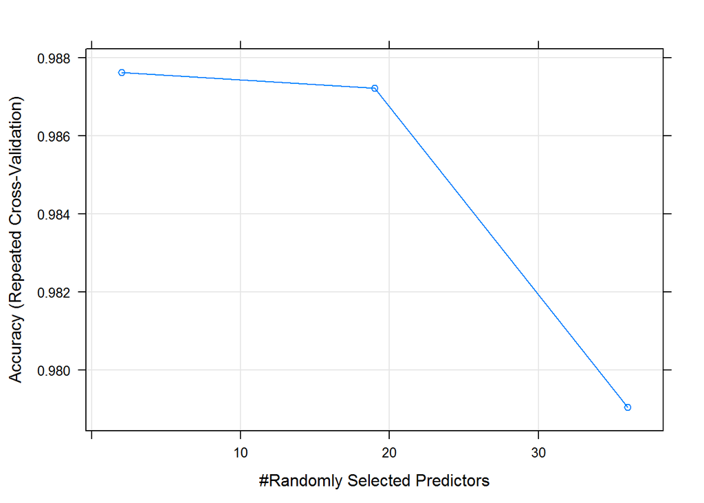

```r
plot(model.fit);
```

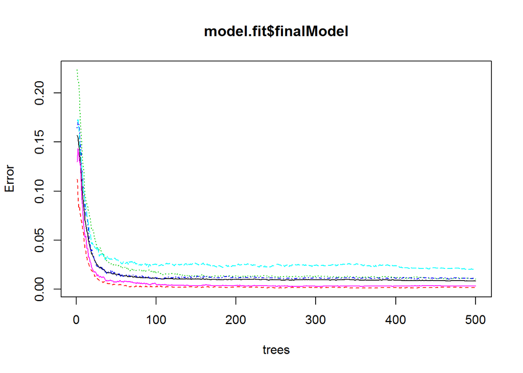

```r
plot(model.fit$finalModel);
```

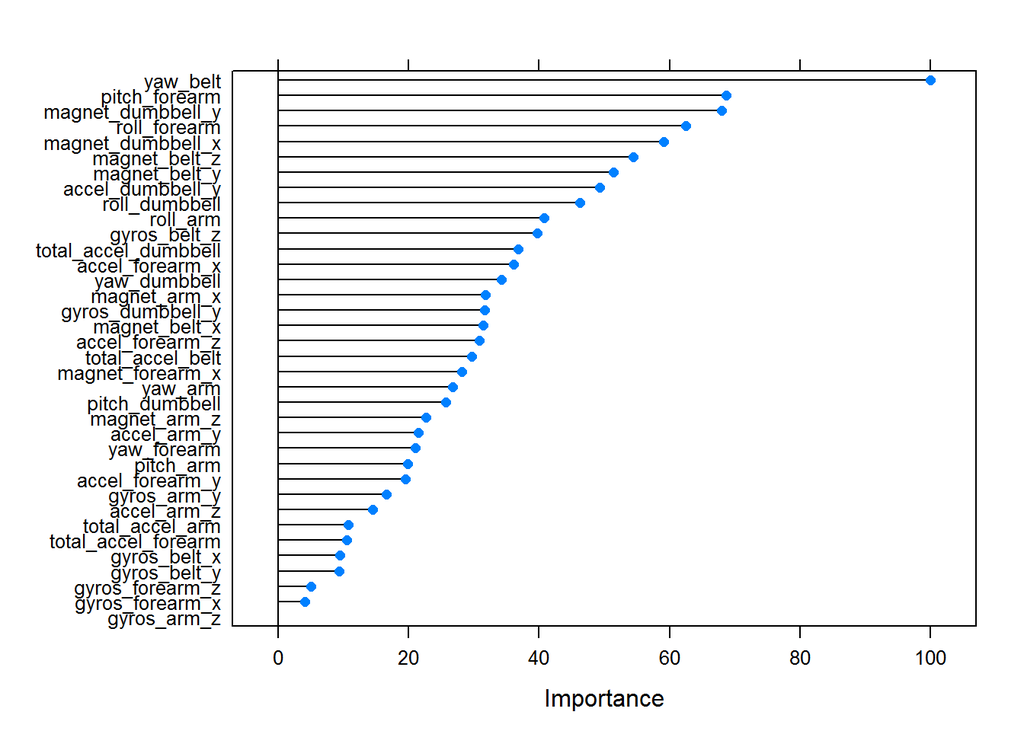

```r
plot(varImp(model.fit));
```

And now I test the model to obtain his quality:

```r
result <- predict(model.fit, df.testing);
confusion.matrix <- confusionMatrix(result, df.testing$classe);
print(confusion.matrix);
```

```
## Confusion Matrix and Statistics
##
##           Reference
## Prediction    A    B    C    D    E
##          A 1390    9    0    0    0
##          B    5  938   10    0    0
##          C    0    2  845   10    0
##          D    0    0    0  794    3
##          E    0    0    0    0  898
##
## Overall Statistics
##
##                Accuracy : 0.992
##                  95% CI : (0.9891, 0.9943)
##     No Information Rate : 0.2845
##     P-Value [Acc > NIR] : < 2.2e-16
##
##                   Kappa : 0.9899
##  Mcnemar's Test P-Value : NA
##
## Statistics by Class:
##
##                      Class: A Class: B Class: C Class: D Class: E
## Sensitivity            0.9964   0.9884   0.9883   0.9876   0.9967
## Specificity            0.9974   0.9962   0.9970   0.9993   1.0000
## Pos Pred Value         0.9936   0.9843   0.9860   0.9962   1.0000
## Neg Pred Value         0.9986   0.9972   0.9975   0.9976   0.9993
## Prevalence             0.2845   0.1935   0.1743   0.1639   0.1837
## Detection Rate         0.2834   0.1913   0.1723   0.1619   0.1831
## Detection Prevalence   0.2853   0.1943   0.1748   0.1625   0.1831
## Balanced Accuracy      0.9969   0.9923   0.9927   0.9934   0.9983
```

# PREDICTIONS

The last step is get the “class” for 20 values of the validation dataset:

```r
validation <- predict(model.fit, df.validation);
print(validation);
```

```
##  [1] B A B A A E D B A A B C B A E E A B B B
## Levels: A B C D E
```

# SAVE THE MODEL

I Save the model for another use:

```r
save(model.fit, file="modelFit.RData");
```